# Day 2 - External Data

07/05/2018

## Welcome back

Remember… we predict the future based on the past

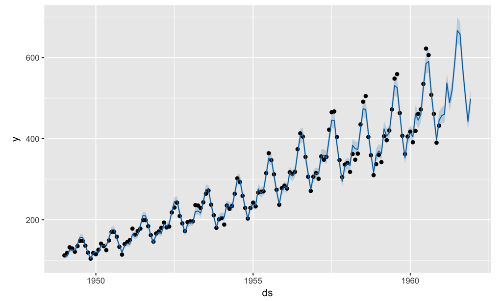

```r
plot(m, forecast)
```

## Including External Data

- **We predict the future based on the past**
- Some movements cannot explained by the past (these are the *residuals*)
- Many things cannot be explained by merely looking at the series
- No season, no trend, no level, no systematic movements

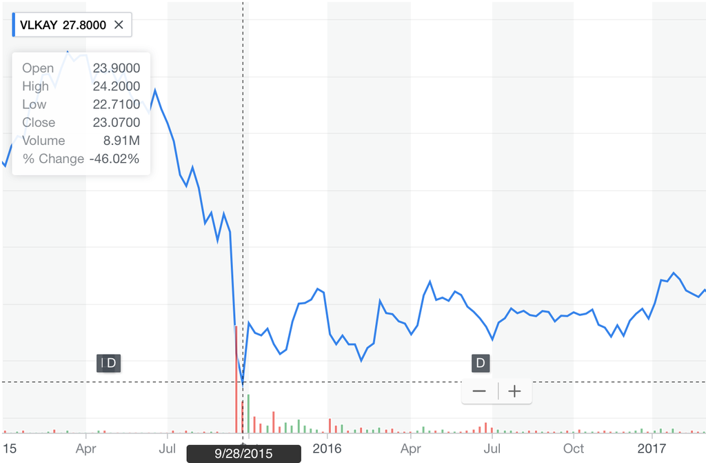

## Influential, External Activity

- Gasoline prices (car sales)
- Weather (icecream consumption)
- Competitor activity
  - ad spend
  - pricing
  - promotions
- Product launches (iPhone launch)
- Black Friday
- Bank Holidays

## Problem: Knowing Future Values

## For which influence factor do you Know its **FUTURE** value?

- Gasoline prices (car sales)
- Weather (icecream consumption)
- Competitor activity
  - ad spend
  - pricing
  - promotions
- Product launches (iPhone launch)
- Black Friday
- Bank Holidays
- Football playoffs

## Some Events are Known Beforehand

- Product launches (iPhone launch)
- Black Friday
- Bank Holidays
- Football playoffs

## Case Study: Wikipedia Load Balancing

## An Example: Load Balancing

Peyton Manning, NFL Quarterback

[figure not shown]

https://da.wikipedia.org/wiki/Peyton_Manning

## Plot Data

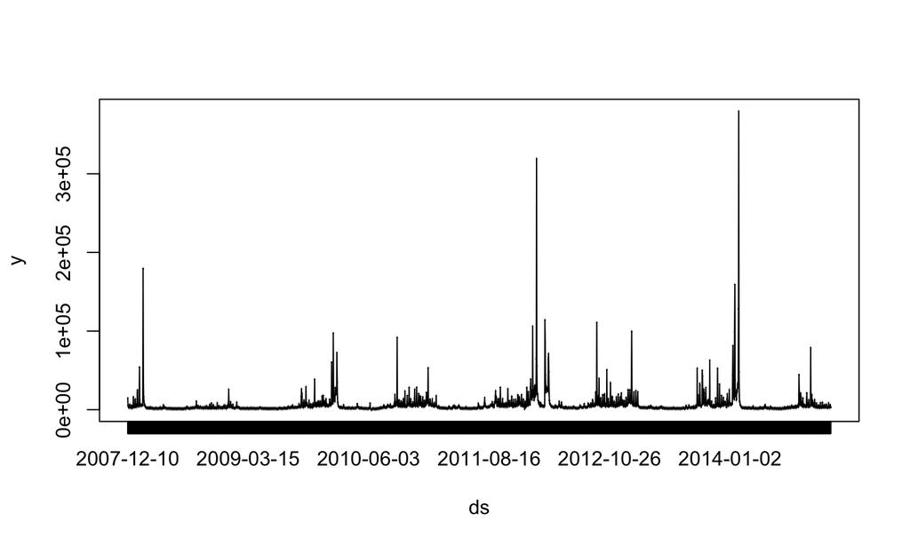

```r
df <- read.csv('data/example_wp_peyton_manning.csv')
plot(df)
lines(df)
```

## Stationarity

The mean of the series should not be a function of time rather should be a constant

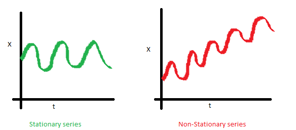

The variance of the series should not a be a function of time

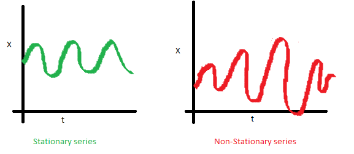

## Stationarity

The covariance of the i th term and the (i + m) th term should not be a function of time. In the following graph, you will notice the spread becomes closer as the time increases. Hence, the covariance is not constant with time for the ‘red series’.

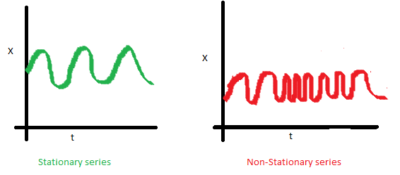

## Make Data Stationary

```r
# load data
df = read.csv('data/example_wp_peyton_manning.csv')
head(df, n=5)
```

```
##           ds     y
## 1 2007-12-10 14629
## 2 2007-12-11  5012
## 3 2007-12-12  3582
## 4 2007-12-13  3205
## 5 2007-12-14  2680
```

## Make Data Stationary

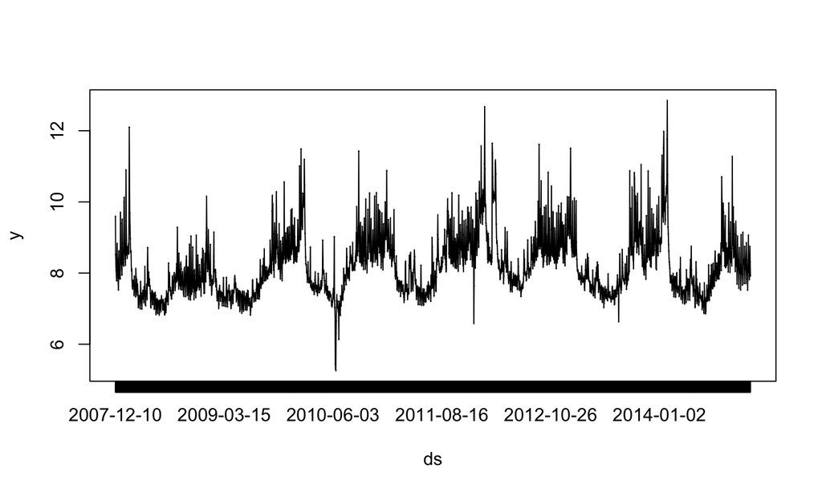

```r
# log-transform data
df['y'] = log(df['y'])
plot(df)
lines(df)
```

## Forecast

```r
library(prophet)
# load data
df = read.csv('data/example_wp_peyton_manning.csv')
head(df, n=5)
```

```
##           ds     y
## 1 2007-12-10 14629
## 2 2007-12-11  5012
## 3 2007-12-12  3582
## 4 2007-12-13  3205
## 5 2007-12-14  2680
```

```r
# log-transform data
df['y'] = log(df['y'])
m = prophet(df)
```

```
## Disabling daily seasonality. Run prophet with daily.seasonality=TRUE to override this.
```

```
## Initial log joint probability = -12.853
## Optimization terminated normally:
##   Convergence detected: relative gradient magnitude is below tolerance
```

```r
future = make_future_dataframe(m, periods = 365)
forecast = predict(m, future)
```

## Plot Forecast

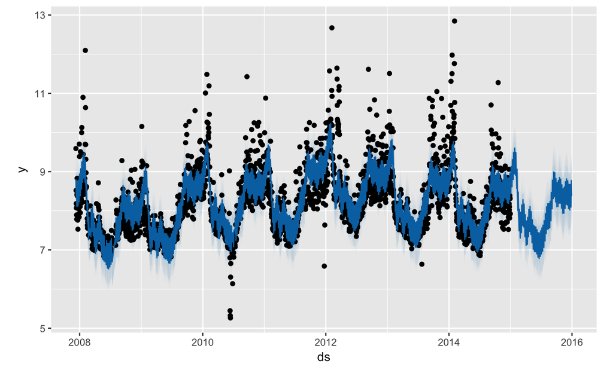

```r
plot(m, forecast)
```

## Notice the Spikes

## Including External Events

```r
playoffs <- data_frame(
  holiday = 'playoff',
  ds = as.Date(c('2008-01-13', '2009-01-03', '2010-01-16',
                 '2010-01-24', '2010-02-07', '2011-01-08',
                 '2013-01-12', '2014-01-12', '2014-01-19',
                 '2014-02-02', '2015-01-11', '2016-01-17',
                 '2016-01-24', '2016-02-07')),
  lower_window = 0,
  upper_window = 1
)
superbowls <- data_frame(
  holiday = 'superbowl',
  ds = as.Date(c('2010-02-07', '2014-02-02', '2016-02-07')),
  lower_window = 0,
  upper_window = 1
)
holidays <- bind_rows(playoffs, superbowls)
```

## Predict with External Events (The Code)

```r
df <- read.csv('data/example_wp_peyton_manning.csv')
# log-transform data
df['y'] = log(df['y'])
# include holidays
m_hol <- prophet(df, holidays = holidays)
```

```
## Disabling daily seasonality. Run prophet with daily.seasonality=TRUE to override this.
```

```
## Initial log joint probability = -12.853
## Optimization terminated normally:
##   Convergence detected: relative gradient magnitude is below tolerance
```

## Predict with External Events (The Code)

```r
# predict
future_hol <- make_future_dataframe(m_hol, periods = 365)
forecast_hol <- predict(m_hol, future_hol)
```

## Including External Events

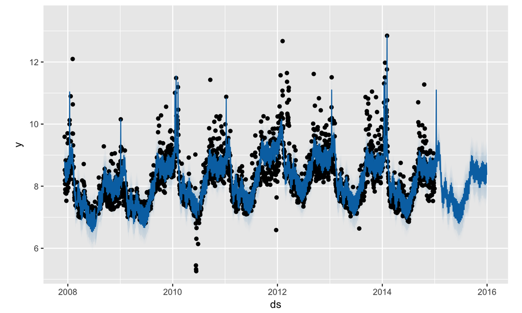

```r
plot(m_hol, forecast_hol)
```

## Including External Events

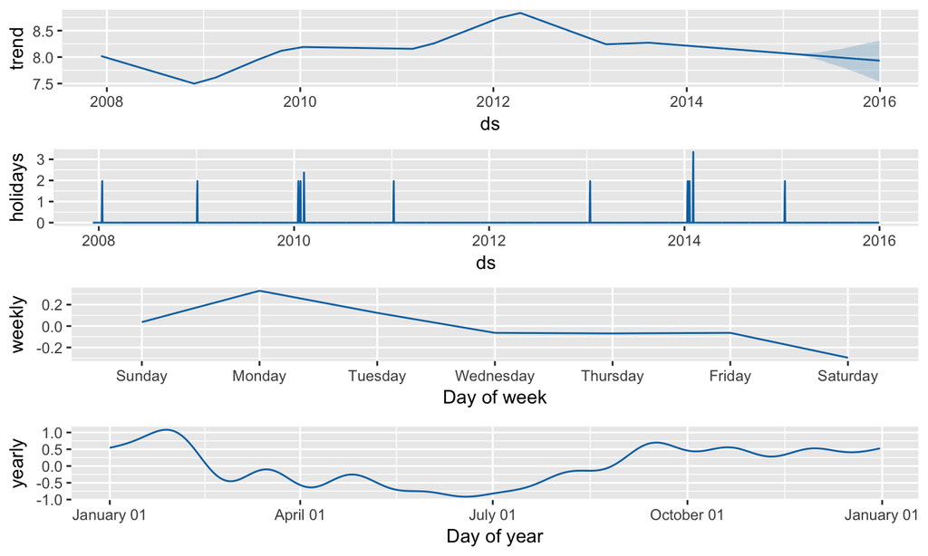

```r
prophet_plot_components(m_hol, forecast_hol)
```

## Compare

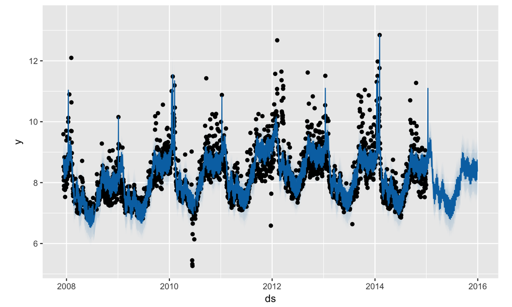

```r
plot(m_hol, forecast_hol)
```

## Compare

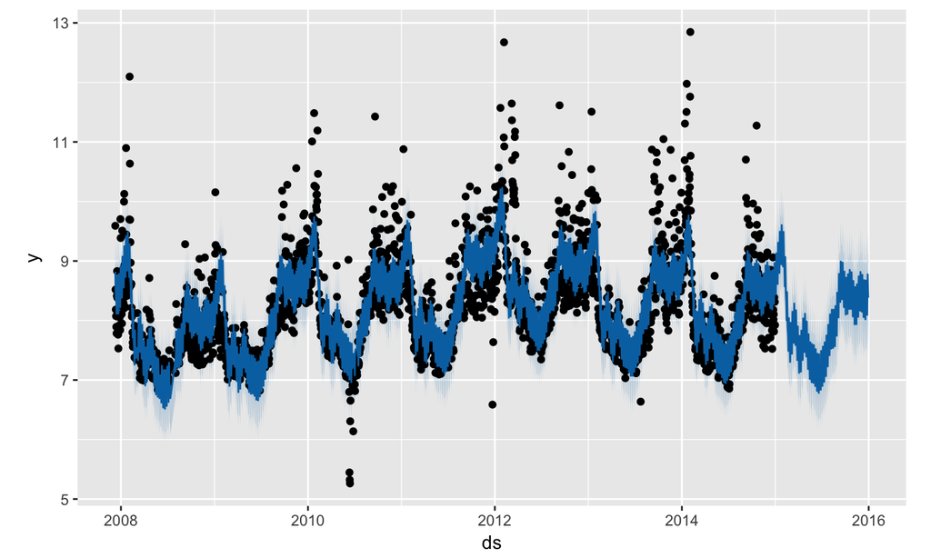

```r
plot(m, forecast)
```

## Recap

## Recap

- Including future values can improve the forecasting accuracy tremendously
- Especially, it can help explain sudden **spikes**
- The Problem: knowing its future value
- Calendar events are well-suited